# Python + HPC

### Jefferson Fialho Coelho

### 17200455 - ADS - Noite

### Agenda

- HPC
  - HPC Cluster Architecture
  - Parallel programming and CPU ark
  - Vectorization
- Python
  - A little bit about language
  - GIL
  - Experiments
    - numexp
- Final explanations
- When am I going to use this thing in my life?
- Career and opportunities

# HPC

## High Performance Computing

The practice of aggregating **computing power** in a way that **delivers much higher performance** than one could get out of a typical desktop computer or workstation in order to solve large **problems in science**, **engineering**, or **business**.

### HPC Cluster Architecture

[figure not shown]

## Parallel programming

[figure not shown]

### CPU ark example

[figure not shown]

# Vectorization

[figure not shown]

### [TOP 1 = SUMMIT: DOE/SC/OAK RIDGE NATIONAL LABORATORY](https://www.top500.org/resources/top-systems/summit-doescoak-ridge-national-laboratory/)

### TOP500.org

[figure not shown]

### Python

- Created by **Guido van Rossum** and first released in **1991**
- Python as a programming language has enjoyed nearly a decade of usage in both **industry and academia**
- **Interpreted, high-level, general-purpose programming language**
- This **high-productivity language** has been one of the most popular abstractions to **scientific computing** and **machine learning**
  - Yet the base Python language remains **single-threaded** =(
- The language's core philosophy ([The Zen of Python](https://www.python.org/dev/peps/pep-0020/)):
  - **Beautiful** is better than ugly
  - **Explicit** is better than implicit
  - **Simple** is better than complex
  - **Complex** is better than complicated
  - **Readability** counts

## Just how is productivity in these fields being maintained with a single-threaded language?

## The reason is the level of abstraction the language design adopted.

- It ships with many tools to wrap C code
- It prefers multiprocessing over multithreading in the base language (multiprocessing package in the native Python library)
- The community has adopted the paradigm to dispatch to higher-speed C-based libraries, and has become the preferred method to implement parallelism in Python (e.g. Intel® MKL, OpenBLAS)

## GIL

- The **Global Interpreter Lock**, or [GIL](https://wiki.python.org/moin/GlobalInterpreterLock), is a mutex that **protects access** to Python objects, **preventing multiple threads** from executing Python bytecodes at once.
- This lock is necessary mainly because **CPython's memory management is not thread-safe**.

## How to cheat? 🤔

[figure not shown]

# Experiments

## NumExpr 2.0

The numexpr package supplies routines for the fast evaluation of array expressions elementwise by using a vectorization.

```python
import math
import sys
import numexpr as ne
import time
import matplotlib.pyplot as plt
import numpy as np

# 10⁶ values between -1.0 and 1.0
x = np.linspace(-1., 1., int(1e6))

# Function to calc sin (serial)
def calc_single(x,i):
    for i in range(i):
        sin = np.sin(2.*np.pi*x)
    return sin

# Function to calc sin (parallel)
def calc_parallel(x,i):
    pi = np.pi
    for i in range(i):
        sin = ne.evaluate('sin(2*pi*x)',
                          optimization = 'aggressive')
    return sin
```

```
10.8 s ± 123 ms per loop (mean ± std. dev. of 7 runs, 1 loop each)
```

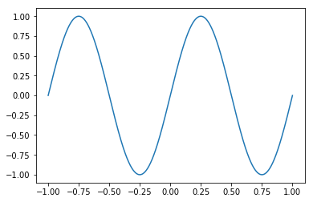

```python
# Get time of 500 serial runs of sin calc
%timeit calc_single(x,500)

# Plot an example of sin
plt.plot(x, calc_single(x,1))
```

```
268 ms ± 3.93 ms per loop (mean ± std. dev. of 7 runs, 1 loop each)
```

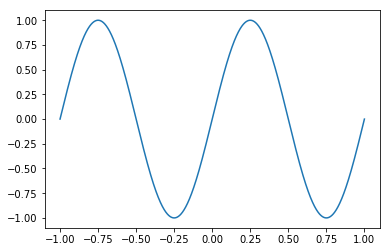

```python
# Get time of 500 parallel runs of sin calc
%timeit calc_parallel(x,500)

# Plot an example of sin
plt.plot(x, calc_parallel(x,1))
```

- **Vectorization commands** from the vector math library in Intel MKL.
- The entire computation **stays in low-level** code before completing and **returning the result** back to the **Python layer**.
- This method also **avoids multiple trips through the Python interpreter**, cutting down on single-threaded sections while also providing a concise syntax.

## Final explanations

- ⬆ Complex, but **simple** (concise)
- ⬆ **Easy to learn** (?)
- ⬆ **Readable** documentation
- ⬆ It's possible to extract **high performance**
- ⬇ **black-box** (some situations)

## When am I going to use this thing in my life?

## When am I going to use this thing in my life?

[figure not shown]

## [Video: ai rough sketches realistic landscapes gaugan](https://mashable.com/video/ai-rough-sketches-realistic-landscapes-gaugan/)

# Career and opportunities

[figure not shown]

[Source: stackoverflow 2018 survey](https://insights.stackoverflow.com/survey/2018/)

[figure not shown]

[Source: Glassdoor](https://www.glassdoor.com/Salaries/javascript-developer-salary-SRCH_KO0,20.htm)

[figure not shown]

[Source: DAXX](https://www.daxx.com/blog/development-trends/python-developer-salary-usa)

## Brazil - Average Python developer salaries (per month)

[figure not shown]

[Source: Lovemondays](https://www.lovemondays.com.br/salarios/cargo/salario-desenvolvedor-python)

## Brazil - Job position salaries (per month)

[figure not shown]

[Source: Lovemondays](https://www.lovemondays.com.br/salarios/cargo/salario-desenvolvedor-python)

# Presentation source

## github:

- http://tiny.cc/tei_jeff